# Explorasi Emisi pada Kendaraan Bermotor

Rahmafatin Izza

2023-11-20

# 1 Introduction

## 1.1 Background

Berdasarkan laporan terbaru *World Air Quality IQAir* 2021 yang dirilis pada Maret 2022, Indonesia menduduki peringkat ke-17 sebagai negara dengan tingkat polusi udara tertinggi di dunia. Polusi udara adalah terkontaminasinya udara oleh zat berbahaya. Penyebab polusi udara salah satunya adalah emisi karbon. Dikutip dari pernyataan Menteri Lingkungan Hidup dan Kehutanan pada Rapat Terbatas Kabinet di Istana Negara, sektor transportasi merupakan penyumbang terbesar emisi karbon sebesar 96,36% atau 28.317 ton per tahun, disusul pembangkit listrik 1,76% atau 5.252 ton per tahun dan industri 1,25% mencapai 3.738 ton per tahun.

Secara umum, nilai emisi pada kendaraan bermotor dapat dihitung berdasarkan **nilai konsumsi bahan bakar** dan **jenis bahan bakar**. Tetapi pada praktiknya, konsumsi bahan bakar juga dipengaruhi oleh gaya berkendara pengguna. Apakah pengguna sering melakukan akselerasi atau pengereman mendadak.Faktor akselerasi dan pengereman mendadak juga dapat dilihat dari jenis jalanan yang dilewati. Apabila pada jalan tol(*Highway*), kecepatan cenderung konstan sehingga nilai konsumsi bahan bakar akan lebih rendah dan menyebabkan emisi karbon pada kendaraan tersebut juga rendah.

Kita akan menggunakan data emisi karbon pada beberapa jenis kendaraan bermotor. Dari data tersebut kita akan mencari informasi tentang bagaimana nilai emisi kendaraan bermotor seperti nilai emisi kendaraan berdasarkan jenis bahan bakar, apakah kecepatan berkendara dapat mempengaruhi nilai emisi karbon, bagaimana jenis transmisi pada kendaraan juga mempengaruhi nilai emisi. Di akhir kita akan melakukan analisis jenis kendaraan apa yang memiliki nilai emisi yang paling kecil.

## 1.2 Data Information

Dataset yang digunakan merupakan dataset dari [Kaggle](https://www.kaggle.com/datasets/debajyotipodder/co2-emission-by-vehicles?select=CO2+Emissions_Canada.csv) Dataset ini merupakan dataset yang sudah di transformasi dari [dataset asli](https://open.Canada.ca/data/en/dataset/98f1a129-f628-4ce4-b24d-6f16bf24dd64#wb-auto-6.) milik pemerintah Canada.

Dataset ini menujukkan nilai emisi pada kendaraan bermotor di Canada, khususnya kendaraan roda 4 keatas, yang dikumpulkan selama 7 tahun.

# 2 Data Preparation

Library preparation

```r
library(rmarkdown)
library(dplyr)
```

## 2.1 Read the data

```r
emission <-  read.csv('data/CO2 Emissions_Canada.csv')
paged_table(head(emission))
```

|  | Make | Model | Vehicle.Class | Engine.Size.L. | Cylinders | Transmission | Fuel.Type | Fuel.Consumption.City..L.100.km. | Fuel.Consumption.Hwy..L.100.km. | Fuel.Consumption.Comb..L.100.km. | Fuel.Consumption.Comb..mpg. | CO2.Emissions.g.km. |
| --- | --- | --- | --- | --- | --- | --- | --- | --- | --- | --- | --- | --- |
| 1 | ACURA | ILX | COMPACT | 2.0 | 4 | AS5 | Z | 9.9 | 6.7 | 8.5 | 33 | 196 |
| 2 | ACURA | ILX | COMPACT | 2.4 | 4 | M6 | Z | 11.2 | 7.7 | 9.6 | 29 | 221 |
| 3 | ACURA | ILX HYBRID | COMPACT | 1.5 | 4 | AV7 | Z | 6.0 | 5.8 | 5.9 | 48 | 136 |
| 4 | ACURA | MDX 4WD | SUV - SMALL | 3.5 | 6 | AS6 | Z | 12.7 | 9.1 | 11.1 | 25 | 255 |
| 5 | ACURA | RDX AWD | SUV - SMALL | 3.5 | 6 | AS6 | Z | 12.1 | 8.7 | 10.6 | 27 | 244 |
| 6 | ACURA | RLX | MID-SIZE | 3.5 | 6 | AS6 | Z | 11.9 | 7.7 | 10.0 | 28 | 230 |

Dari data diatas dapat kita lihat bahwa data kita terdiri dari beberapa kolom, berikut deskripsi dari kolom tersebut:

- **Make**: Perusahaan pembuat kendaraan
- **Model**: Model kendaraan bermotor
- **Vehicle.Class**: kelas kendaraan
- **Engine.Size.L**: Ukuran mesin dalam Liter
- **Cylinders**: Banyak silinder kendaraan
- **Transmission**: Jenis transmisi kendaraan A = automatic AM = automated manual AS = automatic with select shift AV = continuously variable M = manual 3 - 10 = Number of gears
- **Fuel.Type**: Jenis bahan bakar yang digunakan X = regular gasoline Z = premium gasoline D = diesel E = ethanol (E85) N = natural gas
- **Fuel.Consumption.City..L.100.km.**: Konsumsi bahan bakar tiap 100km apabila berjalan di jalanan kota
- **Fuel.Consumption.Hwy..L.100.km.**: Konsumsi bahan bakar tiap 100km apabila berjalan di jalanan tol(highway)
- **Fuel.Consumption.Comb..L.100.km.**: Konsumsi bahan bakar tiap 100km yang di kombinasikan untuk jalanan kota dan highway ((55% city, 45% hwy))
- **Fuel.Consumption.Comb..mpg**: Komsumsi bahan bakar dalam satuan miles per gram
- **CO2.Emission.g.km.**: Emisi karbon kendaraan dalam gram untuk setiap km.

## 2.2 Data Preprocessing

Berdasarkan deskripsi data tersebut, kita tidak akan menggunakan kolom `Fuel.Consumption.Comb..L.100.km`. dan `Fuel.Consumption.Comb..mpg`. Hal ini dikarenakan kolom tersebut merupakan hasil kombinasi dari dua kolom yaitu `Fuel.Consumption.City..L.100.km` dan `Fuel.Consumption.Hwy..L.100.km`. Kedua kolom yang tidak digunakan memiliki informasi yang sama hanya berbeda satuan saja.

```r
emission <- emission %>%
  select(-c("Fuel.Consumption.Comb..L.100.km.", "Fuel.Consumption.Comb..mpg."))
```

### 2.2.1 Duplicated

Kita akan melihat data kita, apakah terdapat data yang duplikat. Kita menggunakan fungsi `duplicated()` untuk melihat apakah satu baris data merupakan duplikat. Fungsi ini akan menghasilkan nilai True apabila baris tersebut terduplikasi. Untuk menghitung banyaknya baris yang duplikat kita bisa menggunakan fungsi `sum()`

```r
sum(duplicated(emission))
```

```
## [1] 1126
```

```r
emission_clean <- emission[!duplicated(emission, fromLast = TRUE),]
```

Dari kode diatas, tanda ! berarti ‘bukan’. Karena fungsi `duplicated()` mengembalikan nilai True apabila baris tersebut identik, maka kita hanya akan mengambil baris yang “bukan True” = “False”. Parameter `fromLast` menunjukkan bahwa kita akan mempertahankan satu dari seluruh baris yang identik yaitu baris terakhir. Sehingga observasi tersebut masih dapat kita manfaatkan

Selanjutnya kita akan coba cek apakah masih terdapat duplikasi identik dari data kita.

```r
paged_table(emission_clean)
```

|  | Make | Model | Vehicle.Class | Engine.Size.L. | Cylinders | Transmission | Fuel.Type | Fuel.Consumption.City..L.100.km. | Fuel.Consumption.Hwy..L.100.km. | CO2.Emissions.g.km. |
| --- | --- | --- | --- | --- | --- | --- | --- | --- | --- | --- |
| 1 | ACURA | ILX | COMPACT | 2.0 | 4 | AS5 | Z | 9.9 | 6.7 | 196 |
| 2 | ACURA | ILX | COMPACT | 2.4 | 4 | M6 | Z | 11.2 | 7.7 | 221 |
| 3 | ACURA | ILX HYBRID | COMPACT | 1.5 | 4 | AV7 | Z | 6.0 | 5.8 | 136 |
| 4 | ACURA | MDX 4WD | SUV - SMALL | 3.5 | 6 | AS6 | Z | 12.7 | 9.1 | 255 |
| 7 | ACURA | TL | MID-SIZE | 3.5 | 6 | AS6 | Z | 11.8 | 8.1 | 232 |
| 8 | ACURA | TL AWD | MID-SIZE | 3.7 | 6 | AS6 | Z | 12.8 | 9.0 | 255 |
| 9 | ACURA | TL AWD | MID-SIZE | 3.7 | 6 | M6 | Z | 13.4 | 9.5 | 267 |
| 10 | ACURA | TSX | COMPACT | 2.4 | 4 | AS5 | Z | 10.6 | 7.5 | 212 |
| 11 | ACURA | TSX | COMPACT | 2.4 | 4 | M6 | Z | 11.2 | 8.1 | 225 |
| 12 | ACURA | TSX | COMPACT | 3.5 | 6 | AS5 | Z | 12.1 | 8.3 | 239 |

[output cut: 6249 more lines]

### 2.2.2 Missing Value

Pengecekan *missing value* pada dataframe dapat dilakukan dengan menggunakan fungsi `is.na()`. Fungsi is.na() akan menghasilkan nilai “True” apabila kolom tersebut terdapat missing value. Kita akan menggabungkan dengan fungsi `colSums()` untuk melihat jumlah *missing value* untuk setiap kolom.

```r
colSums(is.na(emission_clean))
```

```
##                             Make                            Model
##                                0                                0
##                    Vehicle.Class                   Engine.Size.L.
##                                0                                0
##                        Cylinders                     Transmission
##                                0                                0
##                        Fuel.Type Fuel.Consumption.City..L.100.km.
##                                0                                0
##  Fuel.Consumption.Hwy..L.100.km.              CO2.Emissions.g.km.
##                                0                                0
```

Dari pengecekan *missing value*, diketahui bahwa data kita sudah tidak memiliki *missing value*.

### 2.2.3 Feature Engineering

Kita akan melihat data kita

```r
head(emission_clean)
```

|  | Make | Model | Vehicle.Class | Engine.Size.L. | Cylinders | Transmission | Fuel.Type | Fuel.Consumption.City..L.100.km. | Fuel.Consumption.Hwy..L.100.km. | CO2.Emissions.g.km. |
| --- | --- | --- | --- | --- | --- | --- | --- | --- | --- | --- |
| 1 | ACURA | ILX | COMPACT | 2.0 | 4 | AS5 | Z | 9.9 | 6.7 | 196 |
| 2 | ACURA | ILX | COMPACT | 2.4 | 4 | M6 | Z | 11.2 | 7.7 | 221 |
| 3 | ACURA | ILX HYBRID | COMPACT | 1.5 | 4 | AV7 | Z | 6.0 | 5.8 | 136 |
| 4 | ACURA | MDX 4WD | SUV - SMALL | 3.5 | 6 | AS6 | Z | 12.7 | 9.1 | 255 |
| 7 | ACURA | TL | MID-SIZE | 3.5 | 6 | AS6 | Z | 11.8 | 8.1 | 232 |
| 8 | ACURA | TL AWD | MID-SIZE | 3.7 | 6 | AS6 | Z | 12.8 | 9.0 | 255 |

Dari deskripsi data kita yang sudah dipaparkan sebelumnya, kita bisa melakukan *feature engineering* dengan membuat kolom baru dari kolom yang sudah ada. Kolom yang akan digunakan adalah kolom `Transmission`. Pada kendaraan bermotor, jenis transmisi kendaraan dapat mempengaruhi konsumsi bahan bakar.

Nilai pada kolom `Transmission` merupakan gabungan dari jenis transmisi dan jumlah gear. Merujuk kembali ke deskripsi data sebelumnya. Sebagai contoh:

- AS5
  - Jenis transmisi: automatic with select shift
  - Jumlah gear: 5
- M6
  - Jenis transmisi: manual
  - Jumlah gear: 6

Dari informasi tersebut kita bisa mendapatkan informasi tambahan dengan memisahkan nilai angka dan bukan angka.

```r
# Split the string based on the last character
emission_clean <- emission_clean %>%
  mutate(
    Transmission.Type = gsub("[0-9]", "", Transmission), # Remove all numbers
    Gear = ifelse(grepl("\\d", Transmission), gsub("[^0-9]", "", Transmission), 0) # Get only number if they exist, else 0
  )
```

Dari code tersebut kita menggunakan fungsi `mutate()` untuk membuat kolom baru. Fungsi `gsub()` digunakan untuk mengubah sebuah string berdasarkan sebuah pola yang diberikan. Pola yang diberikan adalah [0-9] yang merupakan *regular expression* untuk mencocokkan karakter yang merupakan angka dan [^0-9] merupakan kebalikannya. Sehingga dari fungsi `gsub("[0-9]", "", Transmission)` kita menghilangkan seluruh karakter angka dalam kolom Transmission dan dari fungsi `gsub("[^0-9]", "", Transmission)` kita hanya akan mendapatkan karakter angka dari kolom Transmission.

Pada kolom `Gear` kita mengkombinasikan beberapa fungsi. Fungsi `grepl()` digunakan untuk melakukan pengecekan apakah dalam satu string terdapat sebuah pola atau tidak. `\\d` menunjukkan regular expression untuk mencari digit angka. Singkatnya fungsi `grepl("\\d", Transmission)` akan memberikan nilai `True` apabila nilai tersebut memiliki angka didalamnya.

Fungsi `ifelse()` digunakan untuk mengisi nilai 0 secara *default* apabila dari kolom Transmission tidak memiliki karakter angka. Singkatnya, fungsi `ifelse(grepl("\\d", Transmission), gsub("[^0-9]", "", Transmission), 0)` akan melakukan pengecekan apakah terdapat karakter angka pada kolom Transmission, apabila ada maka akan mengambil nilai angka saja, apabila tidak ada maka akan bernilai 0.

Dari proses ini kita mendapatkan dua kolom baru yaitu:

- Transmission.Type: Jenis transmisi yang digunakan
- Gear: Banyak gear pada kendaraan tersebut.

### 2.2.4 Data Types

Selanjutnya kita akan melakukan pengecekan terhadap struktur data kita. bisa menggunakan fungsi `str()` atau menggunakan `glimpse()`.

```r
glimpse(emission_clean)
```

```
## Rows: 6,259
## Columns: 12
## $ Make                             <chr> "ACURA", "ACURA", "ACURA", "ACURA", "…
## $ Model                            <chr> "ILX", "ILX", "ILX HYBRID", "MDX 4WD"…
## $ Vehicle.Class                    <chr> "COMPACT", "COMPACT", "COMPACT", "SUV…
## $ Engine.Size.L.                   <dbl> 2.0, 2.4, 1.5, 3.5, 3.5, 3.7, 3.7, 2.…
## $ Cylinders                        <int> 4, 4, 4, 6, 6, 6, 6, 4, 4, 6, 12, 8, …
## $ Transmission                     <chr> "AS5", "M6", "AV7", "AS6", "AS6", "AS…
## $ Fuel.Type                        <chr> "Z", "Z", "Z", "Z", "Z", "Z", "Z", "Z…
## $ Fuel.Consumption.City..L.100.km. <dbl> 9.9, 11.2, 6.0, 12.7, 11.8, 12.8, 13.…
## $ Fuel.Consumption.Hwy..L.100.km.  <dbl> 6.7, 7.7, 5.8, 9.1, 8.1, 9.0, 9.5, 7.…
## $ CO2.Emissions.g.km.              <int> 196, 221, 136, 255, 232, 255, 267, 21…
## $ Transmission.Type                <chr> "AS", "M", "AV", "AS", "AS", "AS", "M…
## $ Gear                             <chr> "5", "6", "7", "6", "6", "6", "6", "5…
```

Terdapat kolom yang memiliki tipe data yang belum sesuai yaitu kolom `Make`, `Model`, `Vehicle.Class`, `Transmission`, `Fuel.Type`. Kita akan merubah kolom tersebut menjadi tipe data faktor.

```r
emission_clean <- emission_clean %>%
  mutate_if(.predicate = is.character, .funs = as.factor)
```

Dari struktur data tersebut maka kita akan merubah seluruh kolom yang bertipe `character` menjadi `factor`. Kita bisa merubah menggunakan fungsi `mutate_if()` dari package `dplyr`. Dalam fungsi `mutate_if` kita memasukkan parameter `.predicate` adalah kondisi kolom yang akan kita lakukan perubahan sedangkan parameter `.funs` adalah fungsi yang akan kita gunakan untuk kolom - kolom tersebut. Dari kode diatas berarti kita akan merubah kolom - kolom yang bertipe karakter dan mengaplikasikan fungsi as.factor terhadap kolom tersebut.

Sehingga kolom yang bertipe karakter akan berubah menjadi tipe factor

```r
glimpse(emission_clean)
```

```
## Rows: 6,259
## Columns: 12
## $ Make                             <fct> ACURA, ACURA, ACURA, ACURA, ACURA, AC…
## $ Model                            <fct> ILX, ILX, ILX HYBRID, MDX 4WD, TL, TL…
## $ Vehicle.Class                    <fct> COMPACT, COMPACT, COMPACT, SUV - SMAL…
## $ Engine.Size.L.                   <dbl> 2.0, 2.4, 1.5, 3.5, 3.5, 3.7, 3.7, 2.…
## $ Cylinders                        <int> 4, 4, 4, 6, 6, 6, 6, 4, 4, 6, 12, 8, …
## $ Transmission                     <fct> AS5, M6, AV7, AS6, AS6, AS6, M6, AS5,…
## $ Fuel.Type                        <fct> Z, Z, Z, Z, Z, Z, Z, Z, Z, Z, Z, Z, Z…
## $ Fuel.Consumption.City..L.100.km. <dbl> 9.9, 11.2, 6.0, 12.7, 11.8, 12.8, 13.…
## $ Fuel.Consumption.Hwy..L.100.km.  <dbl> 6.7, 7.7, 5.8, 9.1, 8.1, 9.0, 9.5, 7.…
## $ CO2.Emissions.g.km.              <int> 196, 221, 136, 255, 232, 255, 267, 21…
## $ Transmission.Type                <fct> AS, M, AV, AS, AS, AS, M, AS, M, AS, …
## $ Gear                             <fct> 5, 6, 7, 6, 6, 6, 6, 5, 6, 5, 6, 6, 6…
```

# 3 Exploratory Data Analysis

Kita akan melakukan explorasi pada data kita untuk melihat informasi yang bisa didapatkan dari data kita.

Pertama kita akan melihat bagaimana persebaran nilai emisi karbon pada seluruh kendaraan.

```r
summary(emission_clean$CO2.Emissions.g.km.)
```

```
##    Min. 1st Qu.  Median    Mean 3rd Qu.    Max.
##    96.0   207.0   246.0   251.1   289.0   522.0
```

Dapat dilihat dari persebaran data, kita bisa mengetahui bahwa terdapat perbedaan yang cukup jauh dari nilai minimum dan maksimum emisi yang dihasilkan dari kendaraan bermotor. Rata - rata emisi karbon yang dihasilkan sebuah kendaraan bermotor adalah 251 dan data sebagian besar tersebar di range 200 - 300.

Untuk melihat persebaran kita juga bisa melihat menggunakan visualisasi histogram dari fungsi `hist()`

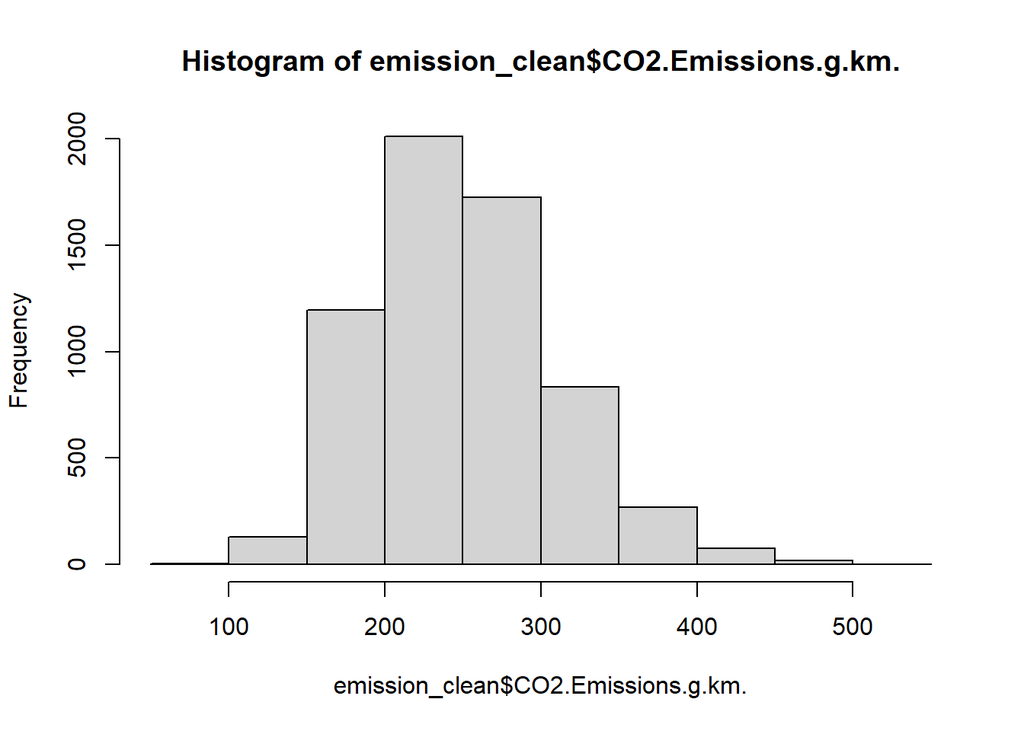

```r
hist(emission_clean$CO2.Emissions.g.km.)
```

sebagian besar kendaraan memiliki nilai emisi sekitar 200 - 300 gram per km.

Selanjutnya kita akan melihat bagaimana konsumsi bahan bakar pada kendaraan bermotor untuk jenis jalan yang berbeda. Pertama kita akan melihat berapa konsumsi bahan bakar apabila berkendala di jalanan kota.

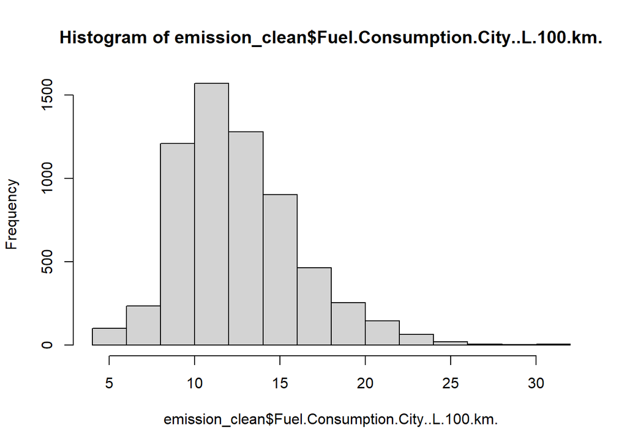

```r
hist(emission_clean$Fuel.Consumption.City..L.100.km.)
```

Dari histogram kita mengetahui bahwa persebaran konsumsi bahan bakar kendaraan bermotor pada jalanan kota sebagian besar berada pada nilai 10 - 15 Liter per 100 km. untuk lebih objektif kita akan melihat dengan menggunakan fungsi `summary()`

```r
summary(emission_clean$Fuel.Consumption.City..L.100.km.)
```

```
##    Min. 1st Qu.  Median    Mean 3rd Qu.    Max.
##    4.20   10.10   12.10   12.61   14.60   30.60
```

Dapat dilihat bahwa nilai konsumsi bahan bakar di jalanan kota memiliki rentang yang cukup besar dengan nilai min 4,2 dan nilai maksimum sebesar 30,6. Dengan median sebagai pusat data, maka konsumsi bahan bakar pada jalanan kota sebagian besar yaitu 12,10 Liter per 100 km.

Selanjutnya kita akan melihat bagaimana konsumsi bahan bakar kendaraan apabila pada jalanan tol (Highway).

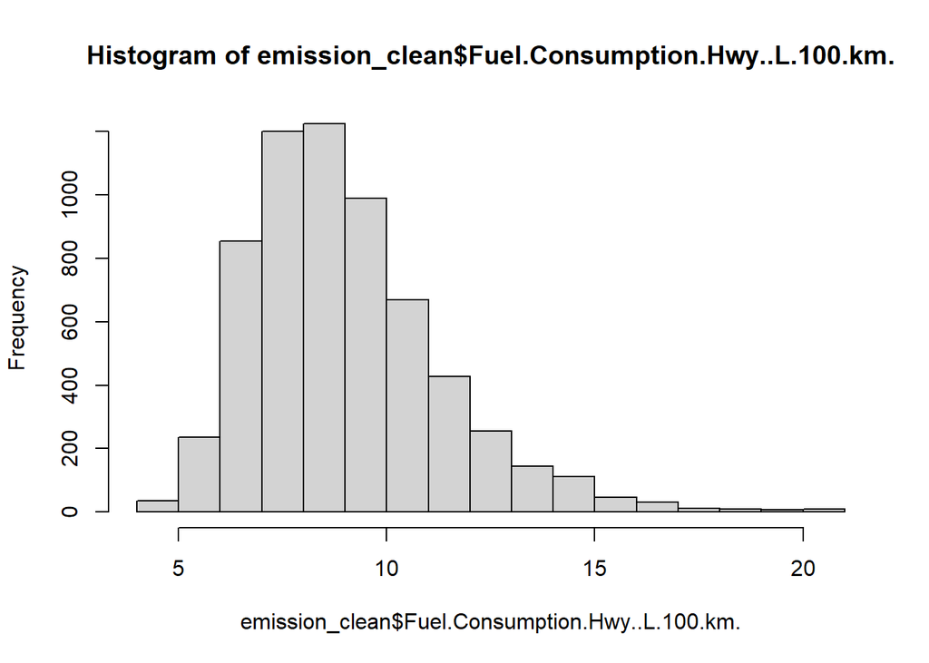

```r
hist(emission_clean$Fuel.Consumption.Hwy..L.100.km.)
```

Konsumsi bahan bakar pada jalanan highway sebagian besar berada pada rentang 5 - 10. Lebih kecil apabila dibandingkan dengan nilai konsumsi bahan bakar pada jalanan kota.

```r
summary(emission_clean$Fuel.Consumption.Hwy..L.100.km.)
```

```
##    Min. 1st Qu.  Median    Mean 3rd Qu.    Max.
##   4.000   7.500   8.700   9.068  10.200  20.600
```

Nilai minimum dan maksimum konsumsi bahan bakar pada jalanan highway lebih berada pada rentang 4 - 20,6. Dengan median sebagai pusat data, konsumsi bahan bakar kendaraan bermotor pada kondisi jalan tol sebagian besar berada pada nilai 8.7. Nilai ini merupakan nilai yang lebih kecil jika dibandingkan dengan median konsumsi bahan bakar untuk jalanan kota.

Selanjutnya kita akan melihat dari data kita, perusahaan produksi kendaraan bermotor apa yang paling banyak digunakan di Canada.

```r
table(emission$Make)
```

```
##
##         ACURA    ALFA ROMEO  ASTON MARTIN          AUDI       BENTLEY
##            72            30            47           286            46
##           BMW       BUGATTI         BUICK      CADILLAC     CHEVROLET
##           527             3           103           158           588
##      CHRYSLER         DODGE          FIAT          FORD       GENESIS
##            88           246            73           628            25
##           GMC         HONDA       HYUNDAI      INFINITI        JAGUAR
##           328           214           210           108           160
##          JEEP           KIA   LAMBORGHINI    LAND ROVER         LEXUS
##           251           231            41            85           178
##       LINCOLN      MASERATI         MAZDA MERCEDES-BENZ          MINI
##            96            61           180           419           204
##    MITSUBISHI        NISSAN       PORSCHE           RAM   ROLLS-ROYCE
##            95           259           376            97            50
##         SCION         SMART           SRT        SUBARU        TOYOTA
##            22             7             2           140           330
##    VOLKSWAGEN         VOLVO
##           197           124
```

Tabel diatas cukup sulit dibaca, kita akan mengurutkan nilai table kita menggunakan fungsi `sort()`.

```r
sort(table(emission$Make), decreasing = TRUE)
```

```
##
##          FORD     CHEVROLET           BMW MERCEDES-BENZ       PORSCHE
##           628           588           527           419           376
##        TOYOTA           GMC          AUDI        NISSAN          JEEP
##           330           328           286           259           251
##         DODGE           KIA         HONDA       HYUNDAI          MINI
##           246           231           214           210           204
##    VOLKSWAGEN         MAZDA         LEXUS        JAGUAR      CADILLAC
##           197           180           178           160           158
##        SUBARU         VOLVO      INFINITI         BUICK           RAM
##           140           124           108           103            97
##       LINCOLN    MITSUBISHI      CHRYSLER    LAND ROVER          FIAT
##            96            95            88            85            73
##         ACURA      MASERATI   ROLLS-ROYCE  ASTON MARTIN       BENTLEY
##            72            61            50            47            46
##   LAMBORGHINI    ALFA ROMEO       GENESIS         SCION         SMART
##            41            30            25            22             7
##       BUGATTI           SRT
##             3             2
```

Ternyata sebagian besar kendaraan yang digunakan di Canada merupakan produksi dari FORD dan CHEVROLET. Hal ini cukup masuk akal mengingat bahwa kedua perusahaan tersebut berpusat di America yang berada tepat di selatan Canada sehingga memungkinkan proses import kendaraan menjadi lebih mudah.

Selanjutnya kita akan melihat jenis transmisi apa yang sering digunakan oleh masyarakat Canada.

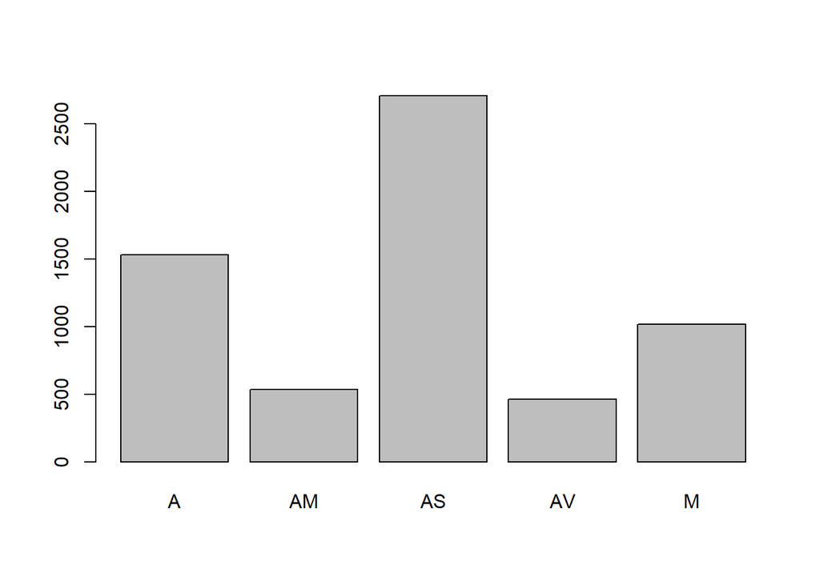

```r
plot(emission_clean$Transmission.Type)
```

Dapat dilihat bahwa tipe transmisi AS (Automatic with Selected Shift) menjadi tipe transmisi yang paling banyak digunakan. Transmisi ini merupakan transmisi otomatis tetapi dilengkapi dengan mode manual, sehingga pengemudi bisa memilih gigi secara manual tanpa pedal kopling. Jenis transmisi ini banyak diminati kemungkinan karena kenyamanan yang ditawarkan dimana pengemudi dapat memilih gigi secara manual tetapi tanpa pedal kopling.

## 3.1 Emission variable analysis

Selanjutnya, Kita akan melakukan analisis terhadap variabel emisi dan bagaimana nilai variabel - variabel lain terhadap emisi kita.

Berikut adalah hal - hal yang akan kita analisis pada explorasi data emisi:

1. Nilai emisi kendaraan berdasarkan konsumsi bahan bakar untuk setiap jenis jalanan.
2. Nilai emisi kendaraan pada setiap jenis bahan bakar.
3. Bagaimana jenis transmisi pada kendaraan mempengaruhi nilai emisi.

Pertama, Kita akan melihat bagaimana hubungan konsumsi bahan bakar kendaraan pada jalanan kota terhadap nilai emisi kendaraan.

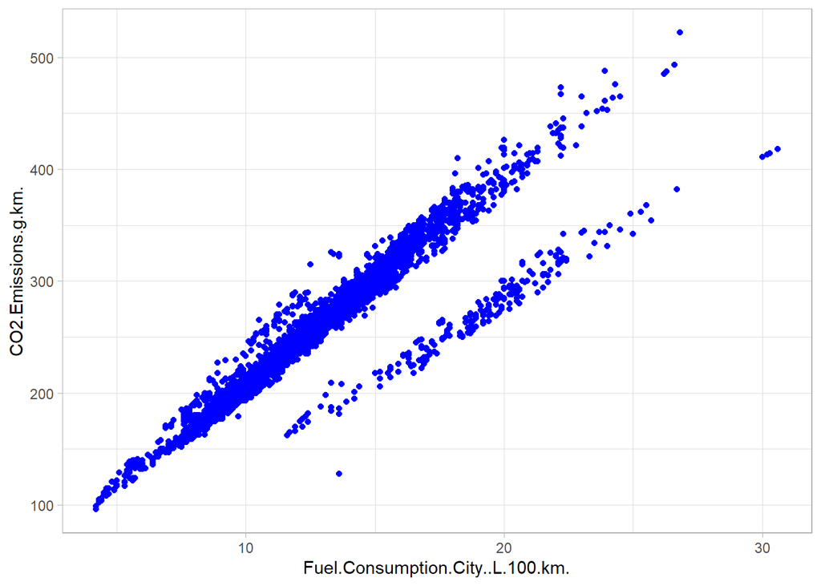

```r
library(ggplot2)
ggplot(data= emission_clean, mapping = aes(x = Fuel.Consumption.City..L.100.km., y = CO2.Emissions.g.km.)) +
  geom_point(color = "blue") +
  theme_light()
```

Dapat dilihat bahwa emisi co2 pada kendaraan bermotor meningkat seiring dengan meningkatnya konsumsi bahan bakar kendaraan bermotor pada jalanan kota. Hal ini cukup masuk akan karena nilai emisi dipengaruhi oleh konsumsi bahan bakar. Selanjutnya kita akan coba membandingkan nilai konsumsi ini dengan kondisi jalanan *Highway.*

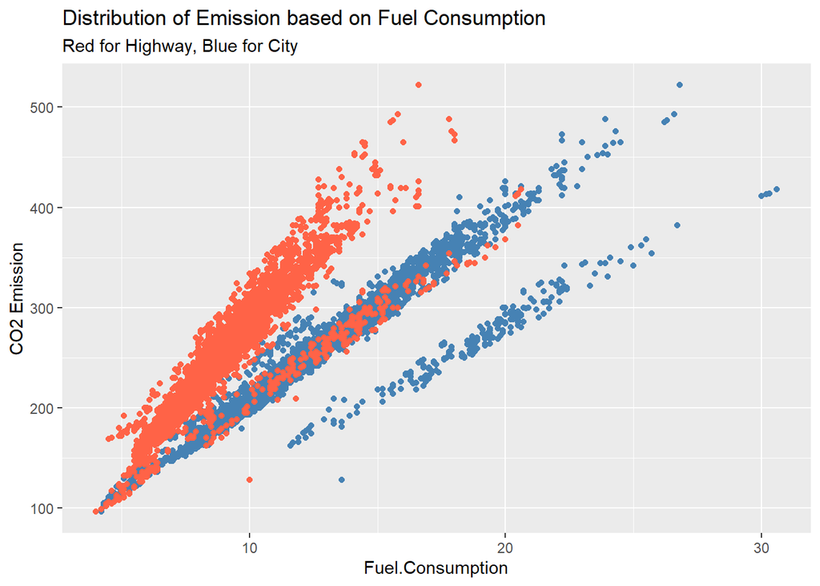

```r
ggplot(data = emission_clean)+
  geom_point(aes(x = Fuel.Consumption.City..L.100.km., y = CO2.Emissions.g.km.), color = "steelblue") +
  geom_point(aes(x = Fuel.Consumption.Hwy..L.100.km., y = CO2.Emissions.g.km.), color = "tomato") +
  labs(
    x = "Fuel.Consumption",
    y = "CO2 Emission",
    title = "Distribution of Emission based on Fuel Consumption",
    subtitle = "Red for Highway, Blue for City"
  )
```

Pada visualisasi diatas, warna biru merupakan konsumsi bahan bakar untuk kondisi jalan kota dan warna merah merupakan konsumsi bahan bakar untuk kondisi jalan *highway.* Dapat dilihat bahwa secara garis besar, kedua grafik menunjukkan informasi yang sama yaitu nilai emisi akan meningkat seiring dengan peningkatan konsumsi bahan bakar. Tetapi, Konsumsi bahan bakar kendaraan bermotor pada jalanan highway cenderung lebih rendah dibandingkan dengan konsumsi bahan bakar pada jalanan kota.

Selanjutnya kita akan melihat bagaimana rata-rata nilai emisi untuk setiap jenis bahan bakar.

```r
# Agregasi data
mean_emission_fuel <- aggregate(CO2.Emissions.g.km. ~ Fuel.Type, emission_clean, mean)

# Rename kolom
names(mean_emission_fuel) <- c("Fuel.Type", "mean_emission")

#Urutkan data
mean_emission_fuel <- mean_emission_fuel[order(mean_emission_fuel$mean_emission, decreasing = T),]

mean_emission_fuel
```

|  | Fuel.Type | mean_emission |
| --- | --- | --- |
| 2 | E | 276.0485 |
| 5 | Z | 265.6325 |
| 4 | X | 235.9145 |
| 1 | D | 235.2381 |
| 3 | N | 213.0000 |

Dapat dilihat bahwa secara rata - rata, nilai emisi karbon untuk setiap jenis bahan bakar tidak memiliki perbedaan yang signifikan. Untuk mempermudah pembacaan, kita akan coba membuat visualisasi dari data tersebut.

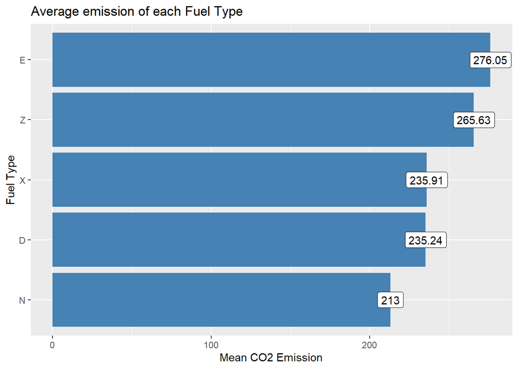

```r
# Create the bar plot
ggplot(mean_emission_fuel, aes(x = mean_emission, y = reorder(Fuel.Type, mean_emission))) +

  geom_col(fill = "steelblue") +
  geom_label(data = mean_emission_fuel,
             aes(label = round(mean_emission, 2)))+
  labs(
    y = "Fuel Type",
    x = "Mean CO2 Emission",
    title = "Average emission of each Fuel Type"
  )
```

Dari visualisasi diatas kita bisa mengetahui bahwa nilai rata-rata emisi karbon untuk setiap bahan bakar tidak memiliki perbedaan yang besar dan berada pada rentang 213 - 277. Tetapi, kita akan mencoba bandingkan dengan melihat persebaran nilai emisi kendaraan berdasarkan setiap jenis bahan bakarnya.

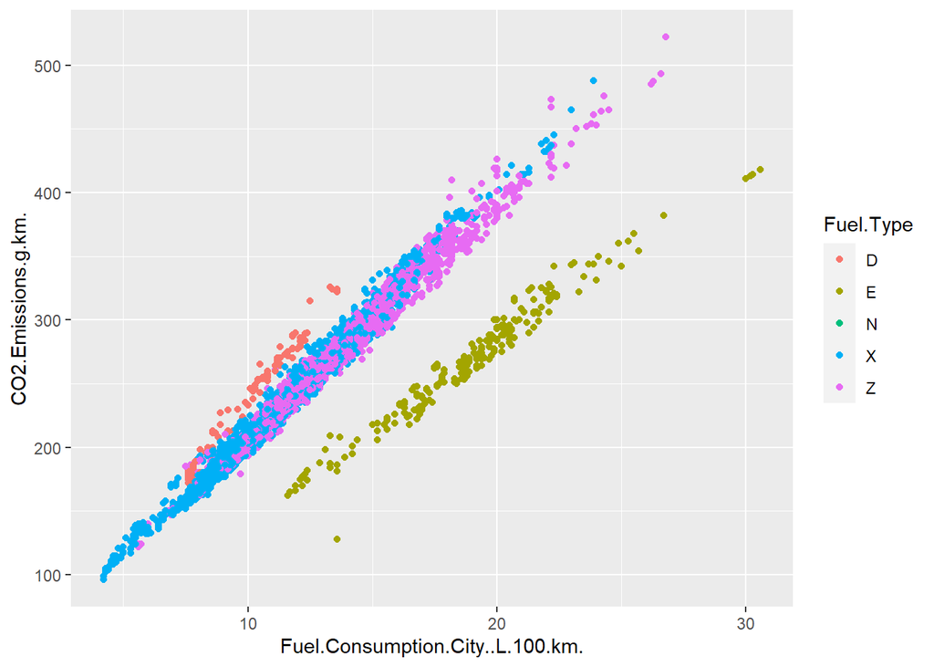

```r
ggplot(data= emission_clean, mapping = aes(x = Fuel.Consumption.City..L.100.km., y = CO2.Emissions.g.km.)) +

  geom_point(aes(color = Fuel.Type))
```

Untuk itu kita akan coba melihat total emisi yang dihasilkan kendaraan untuk setiap jenis bahan bakar.

```r
# Agregasi data
sum_emission_fuel <- aggregate(CO2.Emissions.g.km. ~ Fuel.Type, emission_clean, sum)

# Count the number of rows for each group
sum_emission_fuel$count <- tapply(emission_clean$CO2.Emissions.g.km., emission_clean$Fuel.Type, FUN = length)[sum_emission_fuel$Fuel.Type]

# Rename kolom
names(sum_emission_fuel) <- c("Fuel.Type", "Total Emission", "Vehicle count")

# Urutkan data
sum_emission_fuel <- sum_emission_fuel[order(sum_emission_fuel$`Total Emission`, decreasing = TRUE),]

# Print the result
sum_emission_fuel
```

|  | Fuel.Type | Total Emission | Vehicle count |
| --- | --- | --- | --- |
| 5 | Z | 730755 | 2751 |
| 4 | X | 714821 | 3030 |
| 2 | E | 91096 | 330 |
| 1 | D | 34580 | 147 |
| 3 | N | 213 | 1 |

Dari informasi diatas kita mengetahui bahwa di kanada kendaraan yang menggunakan jenis bahan bakar X (*regular gasoline*) sebanyak hampir 10x dibandingkan kendaraan yang menggunakan jenis bahan bakar E(Ethanol). Tetapi, nilai total emisi yang dihasilkan untuk bahan bakar X (regular gasoline) hanya 7x lebih tinggi dibandingkan total emisi yang dihasilkan untuk bahan bakar E(Ethanol).

Meskipun begitu untuk nilai konsumsi bahan bakar yang sama, nilai emisi kendaraan yang menggunakan bahan bakar ethanol cenderung lebih rendah. Hal ini dapat menjadi indikasi bahwa ethanol memiliki nilai oktan yang lebih tinggi dibandingkan regular gasoline dan kendaraan dengan bahan bakar ethanol memiliki sistem pembakaran yang lebih efektif sehingga emisi karbon lebih sedikit.

Hal ini dapat menjadi indikasi bahwa bahan bakar ethanol dapat menjadi alternatif bahan bakar yang dapat digunakan pada kendaraan bermotor. Bahan bakar ethanol bisa didapatkan dari tanaman seperti tebu, kentang, dan singkong. Hal ini juga dapat menjadi alternatif energi terbarukan yang dapat mengurangi tingkat emisi pada kendaraan bermotor.

Selain jenis bahan bakar, jenis transmisi pada kendaraan dapat mempengaruhi nilai emisi karbon. Pengaruh perbedaan jenis transmisi ini tidak secara langsung mempengaruhi emisi karbon. Tetapi perbadaan jenis transmisi ini dapat mempengaruhi konsumsi bahan bakar yang kemudian dapat mempengaruhi tingkat emisi karbon.

Selanjutnya kita akan melihat bagaimana pengaruh jenis transmisi terhadap rata - rata nilai emisi.

```r
# Aggregasi data
mean_emission_transmission <- aggregate(CO2.Emissions.g.km. ~ Transmission.Type, emission_clean, mean)

# Count the number of rows for each group
mean_emission_transmission$count <- tapply(emission_clean$CO2.Emissions.g.km., emission_clean$Transmission.Type, FUN = length)[mean_emission_transmission$Transmission.Type]

# Order the data
mean_emission_transmission <- mean_emission_transmission[order(mean_emission_transmission$CO2.Emissions.g.km., decreasing = TRUE),]

# Rename the columns
names(mean_emission_transmission) <- c("Transmission.Type", "mean_emission", "Vehicle count")

mean_emission_transmission
```

|  | Transmission.Type | mean_emission | Vehicle count |
| --- | --- | --- | --- |
| 1 | A | 278.3503 | 1533 |
| 3 | AS | 255.5569 | 2708 |
| 2 | AM | 252.0521 | 537 |
| 5 | M | 228.2264 | 1016 |
| 4 | AV | 183.8194 | 465 |

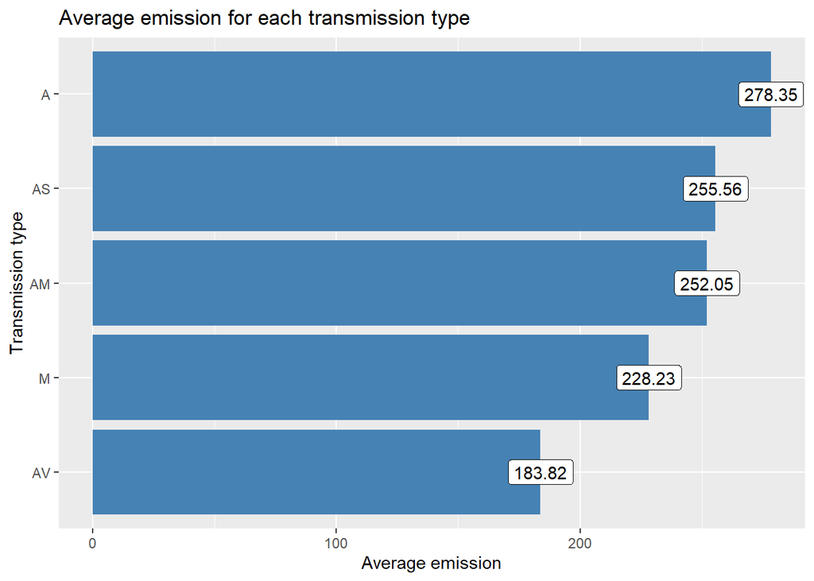

```r
ggplot(data = mean_emission_transmission, aes(x = mean_emission, y = reorder(Transmission.Type , mean_emission))) +
  geom_col(fill = "steelblue")+
  geom_label(aes(label = round(mean_emission,2)))+
  labs(
    x = "Average emission",
    y = "Transmission type",
    title = "Average emission for each transmission type"
  )
```

Dari Informasi diatas didapatkan bahwa Kendaraan dengan jenis transmisi Automatic memiliki rata-rata emisi karbon paling besar. Hal ini bisa dikarenakan kendaraan dengan tipe Automatic mengatur perpindahan gigi secara otomatis berdasarkan kecepatan kendaraan, beban mesin dan lain - lain. Sehingga pengguna tidak dapat mengoptimalkan perpindahan gigi untuk efisiensi bahan bakar. Tetapi, jenis transmisi ini menawarkan kenyamanan berkendara meskipun biasanya kurang efisien dalam konsumsi bahan bakar.

Selain jenis transmisi, Kita juga dapat melakukan analisis terhadap jumlah gear pada suatu kendaraan. Sama seperti jenis transmisi, banyak gear tidak mempengaruhi secara langsung tingkat emisi pada kendaraan bermotor. Tetapi dapat mempengaruhi efisiensi penggunaan bahan bakar.

```r
# Aggregasi data
mean_emission_gear <- aggregate(CO2.Emissions.g.km. ~ Gear, emission_clean, mean)

# Count the number of rows for each group
mean_emission_gear$count <- tapply(emission_clean$CO2.Emissions.g.km., emission_clean$Gear, FUN = length)[mean_emission_gear$Gear]

# Order the data
mean_emission_gear <- mean_emission_gear[order(mean_emission_gear$CO2.Emissions.g.km., decreasing = TRUE),]

# Rename the columns
names(mean_emission_gear) <- c("Gear", "mean_emission", "Vehicle Count")

mean_emission_gear
```

|  | Gear | mean_emission | Vehicle Count |
| --- | --- | --- | --- |
| 3 | 4 | 294.3651 | 63 |
| 2 | 10 | 282.7861 | 187 |
| 7 | 8 | 266.8085 | 1504 |
| 6 | 7 | 266.2383 | 877 |
| 8 | 9 | 247.1033 | 329 |
| 5 | 6 | 243.8028 | 2784 |
| 4 | 5 | 231.4416 | 274 |
| 1 | 0 | 173.4813 | 241 |

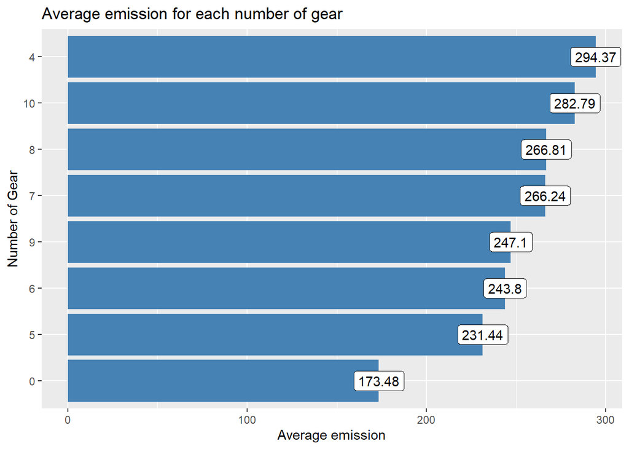

```r
ggplot(data = mean_emission_gear, aes(x = mean_emission, y = reorder(Gear , mean_emission))) +
  geom_col(fill = "steelblue")+
  geom_label(aes(label = round(mean_emission,2)))+
  labs(
    x = "Average emission",
    y = "Number of Gear",
    title = "Average emission for each number of gear"
  )
```

Dapat dilihat bahwa kita tidak dapat mengetahui hubungan langsung antara banyak gear dengan nilai emisi. Kita akan coba melihat hubungan antara banyak gear dengan konsumsi bahan bakar.

```r
# Aggregasi data
mean_consumption_gear <- aggregate(Fuel.Consumption.City..L.100.km. ~ Gear, emission_clean, mean)

# Count the number of rows for each group
mean_consumption_gear$count <- tapply(emission_clean$Fuel.Consumption.City..L.100.km., emission_clean$Gear, FUN = length)[mean_consumption_gear$Gear]

# Order the data
mean_consumption_gear <- mean_consumption_gear[order(mean_consumption_gear$Fuel.Consumption.City..L.100.km., decreasing = TRUE),]

# Rename the columns
names(mean_consumption_gear) <- c("Gear", "mean_consumption", "Vehicle Count")

mean_consumption_gear
```

|  | Gear | mean_consumption | Vehicle Count |
| --- | --- | --- | --- |
| 3 | 4 | 16.134921 | 63 |
| 2 | 10 | 14.068449 | 187 |
| 7 | 8 | 13.335638 | 1504 |
| 6 | 7 | 13.109692 | 877 |
| 5 | 6 | 12.425395 | 2784 |
| 8 | 9 | 12.320061 | 329 |
| 4 | 5 | 11.421168 | 274 |
| 1 | 0 | 8.019087 | 241 |

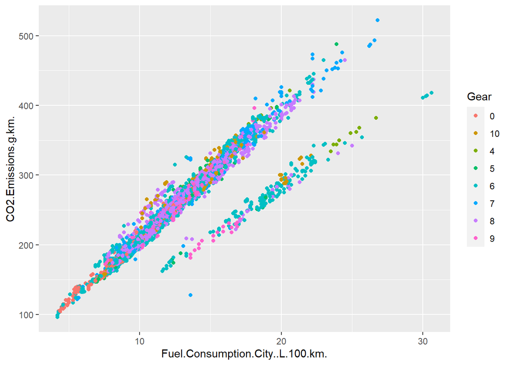

```r
ggplot(data= emission_clean, mapping = aes(x = Fuel.Consumption.City..L.100.km., y = CO2.Emissions.g.km.)) +

  geom_point(aes(color = Gear))
```

Dari visualisasi tersebut, kita tidak dapat meganalisis bagaimana pengaruh banyak gear terhadap konsumsi bahan bakar dan emisi karbon. Sehingga ini dapat menjadi indikasi bahwa gear tidak mempengaruhi secara langsung terhadap emisi pada kendaraan. Hal ini dapat dipengaruhi oleh faktor yang tidak tersedia pada data kita, seperti kemampuan pengguna dalam mengoperasikan gear pada kendaraan dan lain sebagainya.

Selanjutnya kita akan melihat bagaimana nilai emisi karbon kendaraan yang diproduksi oleh setiap perusahaan otomotif.

```r
mean_emission_comp <- aggregate(CO2.Emissions.g.km. ~ Make, emission_clean, mean)

# Order the data
mean_emission_comp <- mean_emission_comp[order(mean_emission_comp$CO2.Emissions.g.km., decreasing = F),]

names(mean_emission_comp) <- c("Company", "mean_emission")

mean_emission_comp
```

|  | Company | mean_emission |
| --- | --- | --- |
| 37 | SMART | 151.4286 |
| 17 | HONDA | 191.2622 |
| 13 | FIAT | 192.2857 |
| 28 | MAZDA | 192.7559 |
| 30 | MINI | 196.5700 |
| 36 | SCION | 200.8095 |
| 31 | MITSUBISHI | 200.8333 |
| 18 | HYUNDAI | 207.9293 |
| 41 | VOLKSWAGEN | 209.8449 |
| 22 | KIA | 213.7969 |

[output cut: 32 more lines]

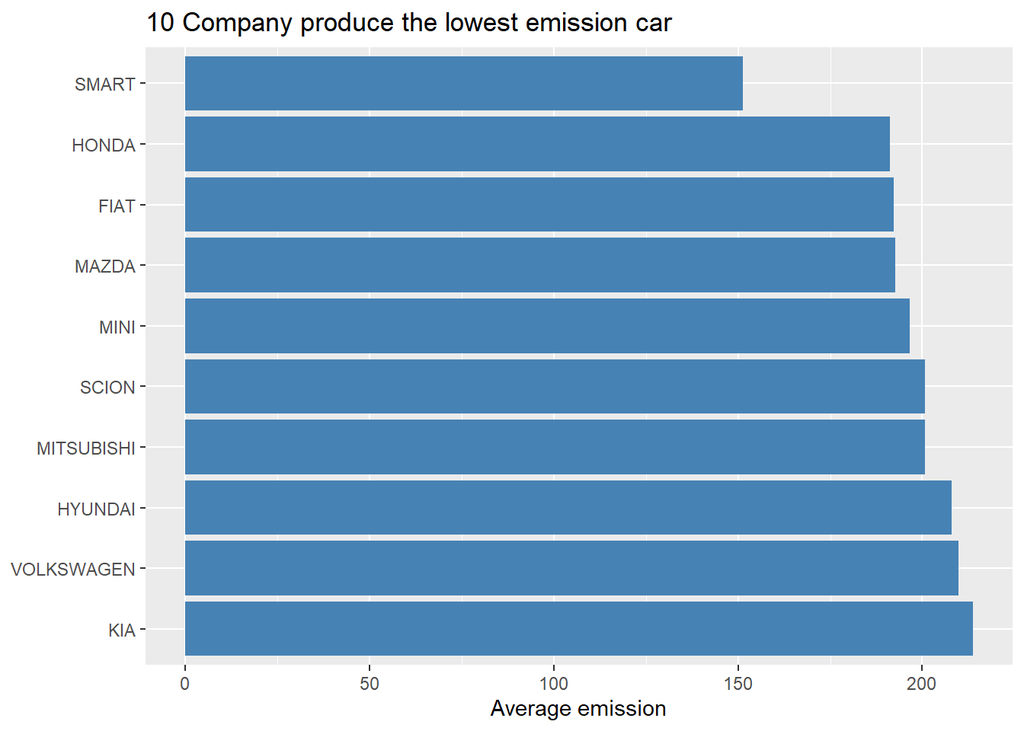

```r
ggplot(data = mean_emission_comp[1:10,], aes(x = mean_emission, y = reorder(Company , -mean_emission))) +
  geom_col(fill = "steelblue")+
  labs(
    x = "Average emission",
    y = NULL,
    title = "10 Company produce the lowest emission car"
  )
```

## 3.2 Conclusion

Dari eksplorasi data yang telah kita lakukan, terdapat beberapa informasi yang bisa kita simpulkan:

- Kendaraan dengan tipe transmisi AV(Continously Variable) atau sering dikenal sebagai CVT memiliki nilai emisi yang terendah. Tipe transmisi ini memungkinkan mesin untuk mengoptimalisasi pembakaran bahan bakar tetapi pengguna tetap dapat melakukan optimalisasi manual. Sehingga tipe ini selain memberikan emisi yang rendah juga memberikan pengalaman berkendara yang nyaman. Tetapi kendaraan bertipe ini masih belum diproduksi secara massive.
- Transmisi kendaraan manual memberikan pengguna kebebasan untuk mengatur perpindahan gigi, sehingga dapat digunakan untuk optimalisasi konsumsi bahan bakar. Hal ini dapat menyebabkan nilai emisi karbon yang berkurang untuk tipe transmisi tersebut.
- Bahan bakar etanol memiliki nilai rata - rata emisi yang tinggi. Tetapi, pada angka konsumsi bahan bakar yang sama bahan bakar etanol memiliki nilai emisi yang rendah dibandingkan dengan jenis bahan bakar lainnya. Hal ini dapat menjadi indikasi bahwa kendaraan yang menggunakan bahan bakar ethanol memiliki teknologi pembakaran yang efektif sehingga residu gas buang menjadi lebih sedikit yang menyebabkan nilai emisi karbonnya makin rendah. Hal ini dapat menjadi alternatif bagi para perusahaan otomotif untuk melihat potensi penggunaan ethanol sebagai bahan bakar alternatif dari energi terbarukan.
- Perusahaan Otomotif Asia seperti Honda, Mazda, Mitsubishi, Hyndai, KIA dapat memproduksi kendaraan dengan nilai emisi yang rendah. Hal ini menjadi indikasi bahwa negara di Asia memiliki potensi perkembangan industri otomotif yang tinggi.

## 3.3 References

- [World Air Quality Report 2021](https://www.iqair.com/id/newsroom/WAQR_2021_PR)
- [Polusi udara di Indonesia](https://www.cnbcindonesia.com/news/20230903164954-4-468635/bukan-pltu-ternyata-ini-penyebab-utama-polusi-di-jakarta)
- [Analisis faktor emisi kendaraan bermotor](https://repository.its.ac.id/56496/1/03211650010012-Master_Thesis.pdf)
- [Bahan bakar ethanol](https://id.wikipedia.org/wiki/Bahan_bakar_etanol)
- [Nilai oktan pada bahan bakar](https://otoklix.com/blog/bilangan-oktan-bensin-jenis-premium/)